# First course project for the Reproducible Research course using Knitr

by Francesco Mancino

## Loading in the data

```r
df<-read.csv("/Users/francescomancino/Desktop/R-programming/Course5/Project1/activity.csv",
             header = TRUE, sep = ",", na.strings = "NA")
```

```r
a1<-aggregate(steps ~ date, data= df, sum, na.rm = TRUE)
sm<- mean(a1$steps)
smed<- median(a1$steps)
```

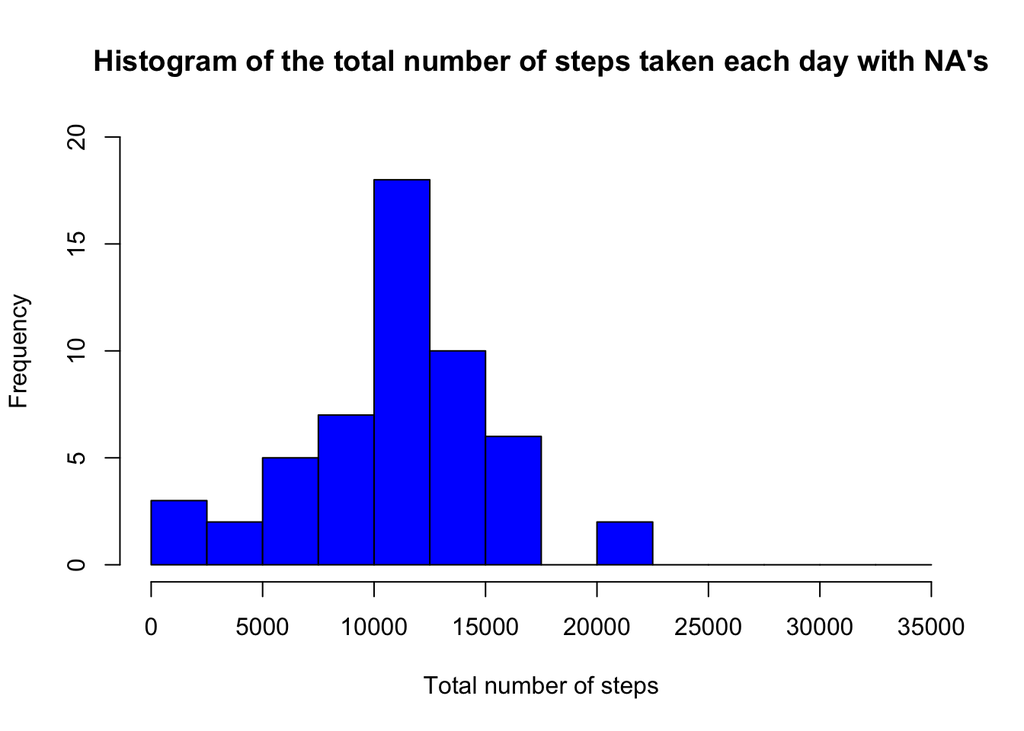

```r
hist(a1$steps,
      breaks=seq(from=0, to=35000, by=2500),
      col="blue",
      xlab="Total number of steps",
      ylim=c(0, 20),
      main="Histogram of the total number of steps taken each day with NA's")
```

##2. What is the average daily activity pattern?

The average daily activity is presented in the next plot

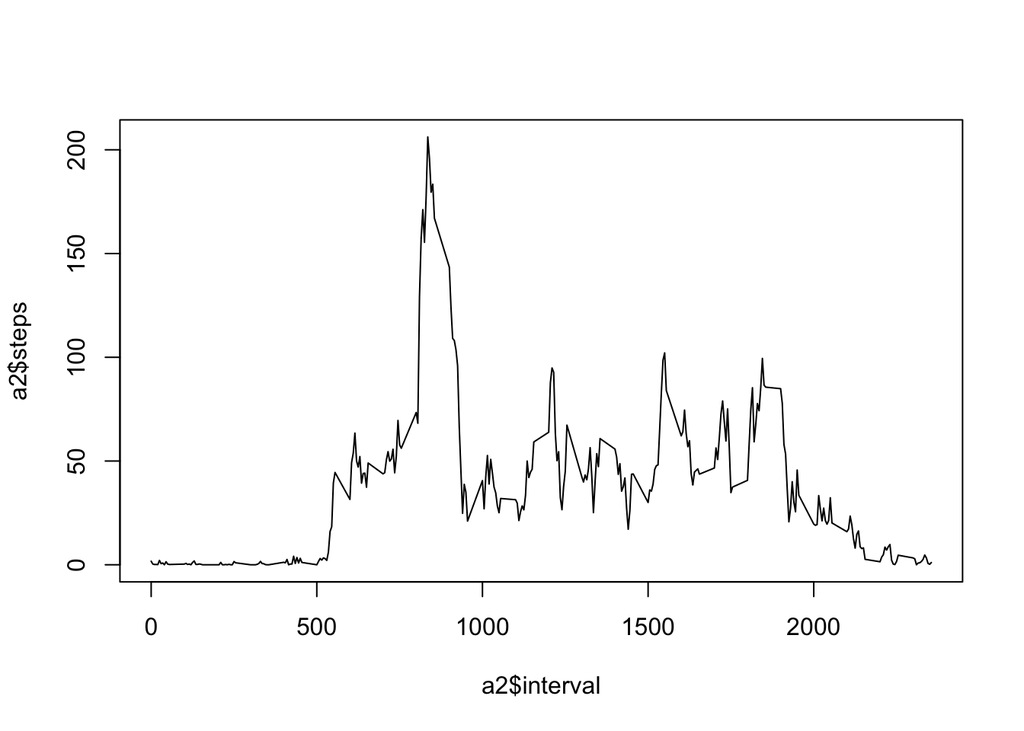

```r
a2<-aggregate(steps ~ interval, data= df, mean, na.rm = TRUE)
plot(a2$interval, a2$steps, type = "l")
```

The 5-minute interval that on average across all the days in the data set, contains the maximum number of steps is:

```r
max_pos <- which(a2$steps == max(a2$steps))
max_interval<- a2[max_pos, 1]
print(max_interval)
```

```
## [1] 835
```

## 3. Imputing missing values

```r
na_count<-sum(is.na(df$steps))
```

There are 2304 missing values in the data set.

The strategy for imputing the missing values is presented in the following code chunk:

```r
tidydf<-df
tidydf$steps[is.na(tidydf$steps)] <- median(df$steps, na.rm=TRUE)
```

```r
a3<-aggregate(steps ~ date, data= tidydf, sum)
newmean<- mean(a3$steps)
newmedian<- median(a3$steps)
```

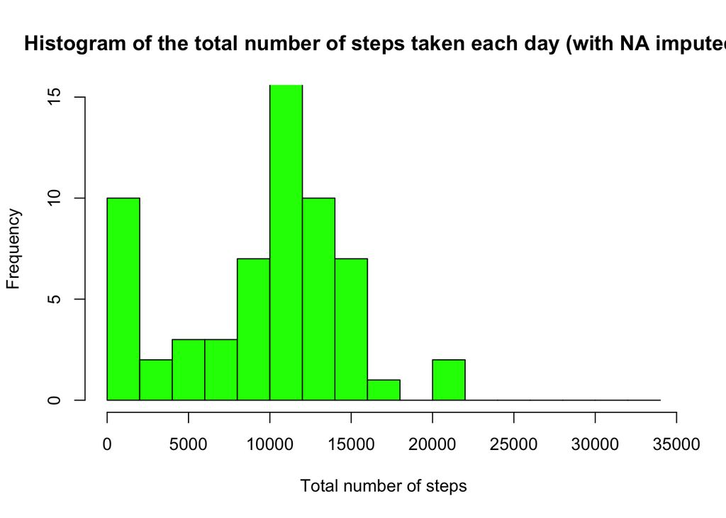

```r
hist (a3$steps,
     breaks=seq(from=0, to=35000, by=2000),
     col="green",
     xlab="Total number of steps",
     ylim=c(0, 15),
     main="Histogram of the total number of steps taken each day (with NA imputed)")
```

## 4. Are there differences in activity patterns between weekdays and weekends?

```r
tidydf$day=weekdays(as.Date(df$date))
wday =subset(tidydf, ! day %in% c("Saturday","Sunday"))
wkend =subset(tidydf,  day %in% c("Saturday","Sunday"))
tidydf<- rbind(tidydf, wday, wkend)
tidydf$weekend <- as.factor (ifelse(tidydf$day== "Saturday" |
                                tidydf$day== "Sunday", "weekend","weekday"))
```

The previous code prepared the data set with the the sub setting of weekdays and weekends for answering question #4.

The time series plot for both weekdays and weekends is:

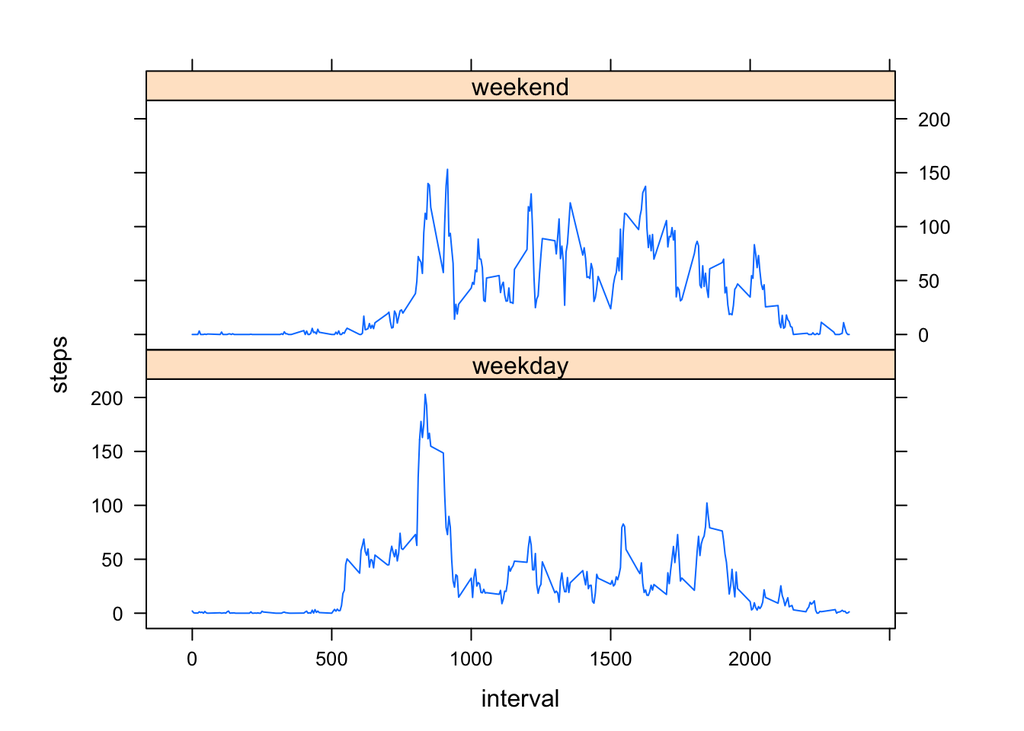

```r
a4<-aggregate(steps ~ interval + weekend, data= tidydf, mean)
library(lattice)
xyplot(steps ~ interval | factor(weekend), data=a4, aspect=1/3, type="l")
```